# A Study Guide for Quiz 3

Author

Jed Rembold

Published

April 23, 2025

The below materials are meant to provide you a sort of checklist of what you should ensure you are aware of going into the third quiz, as well as providing some example type questions. I’ve included a list of equations you should know as well.

# 1 Outline of Content

**Unit 5: Dark Matter**

- For increases or decreases in enclosed mass or radius, how does the speed of an orbiting object change?
- **Computing:** For a constant density object, what sort of radial velocity curve would we expect to see?
- What is our rationale behind the existence of dark matter?
- How does the distribution of dark matter in a galaxy compare to the distribution of visible matter?
- What are other dim sources of mass that we have tried to account for?

**Unit 5: Cosmology**

- Hubble’s Relation
  - What trend did Hubble see when looking at distant galaxies?
  - How is redshift ($z$) related to velocity?
  - **Computing:** Given a value for Hubble’s constant and a redshift velocity, what distance away is the object?
  - Approximately what are the currently accepted values of Hubble’s constant?
  - How do we explain how everything could be moving away from us, and yet not have us in the center of the universe?
  - What is the cosmological principle?
  - How does Hubble’s constant relate to the age of the universe?
- Cosmology
  - What does $\Omega$ describe in layman’s terms?
  - How does $\Omega$ relate to the curvature of the universe?
    - How does $\Omega_k$ relate to the curvature of the universe?
  - What are three ways we can attempt to measure $\Omega$?
  - What shocked astronomers at the turn of the millennium when they plotted the Hubble relation out to greater distances?
  - Based on this information, was Hubble’s parameter in the past greater or less than it is today?
  - What do we ascribe to the accelerating expansion of the universe?
  - How do we break $\Omega$ but into its various parts? What are the approximately measured values of each currently?
  - What is recombination, and why is it the furthest “back” we could look with modern light-based telescopes?
  - What is the Cosmic Microwave Background?
  - What can we conclude by looking at the structure of the CMB?
  - What are some problems or concerns that the structure of the CMB raises?

**Equations to Know**

There aren’t many equations you need to know to be able to solve the computing objectives for these sections:

$$v(r) = \sqrt{\frac{GM_{in}}{r}}$$

$$v = Hd$$

# 2 Example Problems

**Question 1**

What two quantities did Edwin Hubble compare for a sample of galaxies to discover the expansion of the universe?

1. Luminosity and distance
2. Age and distance
3. Velocity and distance
4. Luminosity and temperature
5. Velocity and temperature

**Answer**

What two quantities did Edwin Hubble compare for a sample of galaxies to discover the expansion of the universe?

1. Luminosity and distance
2. Age and distance
3. **Velocity and distance**
4. Luminosity and temperature
5. Velocity and temperature

**Question 2**

Dr. X believes that the Hubble constant is $H = 50$ km/s/Mpc, whereas Dr. Y believes that the Hubble constant is $H = 70$ km/s/Mpc. Which statement below automatically follows?

1. Dr. X believes that the universe is expanding, but Dr. Y does not.
2. Dr. X believes that the universe is older than Dr. Y believes.
3. Dr. X believes that the universe will someday stop expanding, while Dr. Y believes it will expand forever.
4. Dr. X believes that the universe has a much higher density parameter than Dr. Y believes.

**Answer**

Dr. X believes that the Hubble constant is $H = 50$ km/s/Mpc, whereas Dr. Y believes that the Hubble constant is $H = 70$ km/s/Mpc. Which statement below automatically follows?

1. Dr. X believes that the universe is expanding, but Dr. Y does not.
2. **Dr. X believes that the universe is older than Dr. Y believes.**
3. Dr. X believes that the universe will someday stop expanding, while Dr. Y believes it will expand forever.
4. Dr. X believes that the universe has a much higher density parameter than Dr. Y believes.

**Question 3**

A distant galaxy is observed to be moving away from us at 144,000 m/s. How far away is it from us, assuming a Hubble constant of 72 km/s/Mpc?

**Answer**

We know that
$$v = Hd$$
and thus that
$$d = \frac{v}{H}$$
Making sure we are consistent with our units:
$$d = \frac{144 \text{ km/s}}{72\text{ km/s/Mpc}} = 2\text{ Mpc}$$

**Question 4**

Explain why it is impossible for us to optically look past the cosmic microwave background.

**Answer**

The CMB depicts the state of the universe at the time of recombination. Looking past the CMB would be like looking into an era before recombination. During this time though, the universe was still hot enough that atoms were ionized, and thus light produced from this time period was scattered, making the surface appear opaque.

**Question 5**

What is responsible for the increasing acceleration of the universe?

1. Visible matter
2. Dark matter
3. Dark energy
4. Neutrinos

**Answer**

What is responsible for the increasing acceleration of the universe?

1. Visible matter
2. Dark matter
3. **Dark energy**
4. Neutrinos

**Question 6**

Explain how Hubble’s discovery of the relationship between galactic distance and redshift led to the idea of the Big Bang.

**Answer**

Hubble discovered the rate at which all galaxies appeared to be moving away from us. If this was the rate that the universe was expanding, then it stood to reason that, if played backwards, the universe would get smaller and smaller, until at some point it must have come from a tiny nothing. The idea of the Big Bang sprang from this notion of an outward explosion of the universe starting from a tiny nothing.

**Question 7**

Why do we believe that most of the mass of the Milky Way is in the form of dark matter?

1. Theoretical models of galaxy formation suggest that a galaxy can not form unless it has at least 10 times as much matter as we see in the Milky Way disk, suggesting that the halo must be full of dark matter.
2. Although dark matter emits no visible light, it can be seen with radio wavelengths, and such observations confirm that the halo is full of this material.
3. Our view of distant galaxies is sometimes obscured by dark blotches in the sky, and we believe these blotches are dark matter located in the halo.
4. The orbital speeds of stars far from the galactic center are surprisingly high, suggesting that these stars are feeling gravitational effects from unseen matter in the halo.

**Answer**

Why do we believe that most of the mass of the Milky Way is in the form of dark matter?

1. Theoretical models of galaxy formation suggest that a galaxy can not form unless it has at least 10 times as much matter as we see in the Milky Way disk, suggesting that the halo must be full of dark matter.
2. Although dark matter emits no visible light, it can be seen with radio wavelengths, and such observations confirm that the halo is full of this material.
3. Our view of distant galaxies is sometimes obscured by dark blotches in the sky, and we believe these blotches are dark matter located in the halo.
4. **The orbital speeds of stars far from the galactic center are surprisingly high, suggesting that these stars are feeling gravitational effects from unseen matter in the halo.**

**Question 8**

Consider the mass distribution profiles below, which depict how much mass is located within a narrowband a particular distance from the center of an orbit.

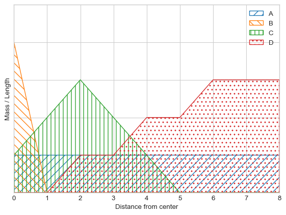

For which distribution would an object orbiting at a distance of $r=4$ have the *slowest* velocity?

**Answer**

For points the same distance from the center, we know that the velocity is proportional to $\sqrt{M_{in}}$. Given a plot of the mass per length at different distances, the area under the curve to the left of $r=4$ would give us $M_{in}$. So we just need to compute the area of some triangles:

$$\begin{aligned}
A &= 4 \times 1 = 4 \\
B &= \frac{4\times 1}{2} = 2 \\
C &= (4 \times 1) + \frac{4\times2}{2} = 8 \\
D &= (2 \times 1) + 2 \times \frac{1\times1}{2} = 3
\end{aligned}$$

And thus we see that distribution B would result in the slowest orbiting objects at $r=4$.

**Question 9**

Visible, luminous matter (such as stars within galaxies) amounts to what percentage of the total mass density of the universe?

1. less than 2%
2. 6%
3. 30%
4. 70%

**Answer**

Visible, luminous matter (such as stars within galaxies) amounts to what percentage of the total mass density of the universe?

1. **less than 2%**
2. 6%
3. 30%
4. 70%

**Question 10**

Suppose the cosmic microwave background had been discovered instead at a much longer wavelength, say large radio waves. This could have implied any of the following *except*:

1. The universe is older than we thought
2. The early universe was not as hot as we thought
3. Recombination happened earlier in the universe’s timeline than we thought
4. The universe is smoother than we thought

**Answer**

Suppose the cosmic microwave background had been discovered instead at a much longer wavelength, say large radio waves. This could have implied any of the following *except*:

1. The universe is older than we thought
2. The early universe was not as hot as we thought
3. Recombination happened earlier in the universe’s timeline than we thought
4. **The universe is smoother than we thought**